# Depersonalized extended contact and injunctive norms about cross-group friendship impact intergroup orientations - ScienceDirect

## Outline

1. Abstract
2. 1. Extended contact and ingroup and outgroup norms
3. 2. The impact of social norms on intergroup orientations
4. 3. Overview of the present research
5. 4. Preliminary study
6. 5. Experiment 1
7. 6. Experiment 2
8. 7. Experiment 3
9. 8. Experiment 4
10. 9. Experiment 5
11. 10. General discussion
12. 11. Channeling impersonal extended contact into direct contact
13. 12. Limitations
14. 13. Conclusions
15. Open practices
16. References

## Figures (4)

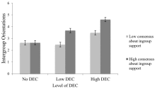

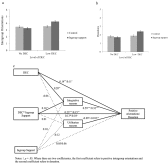

## Tables (3)

1. Table 1
2. Table 2
3. Table 3

## [Journal of Experimental Social Psychology](https://www-sciencedirect-com.ezproxy.spu.edu/science/journal/00221031)

[Volume 76](https://www-sciencedirect-com.ezproxy.spu.edu/science/journal/00221031/76/supp/C), May 2018, Pages 356-370

# Depersonalized extended contact and injunctive norms about cross-group friendship impact intergroup orientations☆

[ÁngelGómez<sup>a</sup><sup>e</sup>](https://www-sciencedirect-com.ezproxy.spu.edu/science/article/pii/S0022103117305462#!)[Linda R.Tropp<sup>b</sup>](https://www-sciencedirect-com.ezproxy.spu.edu/science/article/pii/S0022103117305462#!)[AlexandraVázquez<sup>a</sup>](https://www-sciencedirect-com.ezproxy.spu.edu/science/article/pii/S0022103117305462#!)[AlbertoVoci<sup>c</sup>](https://www-sciencedirect-com.ezproxy.spu.edu/science/article/pii/S0022103117305462#!)[MilesHewstone<sup>d</sup><sup>f</sup>](https://www-sciencedirect-com.ezproxy.spu.edu/science/article/pii/S0022103117305462#!)

[https://doi.org/10.1016/j.jesp.2018.02.010](https://doi-org.ezproxy.spu.edu/10.1016/j.jesp.2018.02.010)[Get rights and content](https://s100.copyright.com/AppDispatchServlet?publisherName=ELS&contentID=S0022103117305462&orderBeanReset=true)

## Abstract

Five experiments examine the interactive power of descriptive and injunctive norms regarding intergroup friendships on the effects of extended contact – knowing ingroup members having outgroup friends – on intergroup orientations. We propose that the positive effect of extended contact can occur even when the ingroup members having outgroup friends are unknown to the individual who becomes aware of such contact – depersonalized extended contact. However, to be effective depersonalized extended contact requires ingroup normative support. We tested this prediction by providing participants with information about the number of ingroup members (Spaniards) who have outgroup (immigrants) friends -descriptive norms - and the normative support for cross-group friendship -injunctive norms. Three experiments tested how different levels of depersonalized extended contact (none vs. low vs. high), consensus regarding norms about cross-group friendship (low vs. high), and the source of such norms (ingroup vs. outgroup) impact intergroup orientations. Even low levels of depersonalized extended contact had positive effects on intergroup orientations, when there was normative support for cross-group friendship from the ingroup, but not from the outgroup. Two additional experiments extended these effects to a behavioral outcome, and showed that the positive effect of ingroup injunctive norms was mediated by the enhanced belief that outgroup members had a genuine interest in intergroup contact (integrative motives). However, the lack of effect of outgroup injunctive norms was mediated by the suspicion that outgroup members held utilitarian motives for contact. Implications of these findings for improving [intergroup relations](https://www-sciencedirect-com.ezproxy.spu.edu/topics/psychology/intergroup-relations) through depersonalized extended contact and injunctive normative influence are discussed.

Learning that an ingroup member has outgroup friends has a positive impact on intergroup attitudes (e.g., the extended contact effect, Wright, Aron, Mclaughlin-Volpe, & Ropp, 1997). Whereas research on extended contact has typically focused on individuals who *know* other ingroup members who have outgroup friends, here we propose and tested for the first time that learning that ingroup members *in general* have outgroup friends may also lead to positive intergroup orientations. We call this type of indirect contact involving unknown ingroup members ‘depersonalized extended contact’, which, for brevity, we abbreviate to DEC in this paper. In five experiments we examine the effects of DEC and how these effects can be maximized. Literature on social norms and persuasion suggests that acknowledging that ingroup members support cross-group friendship might reinforce the impact of extended contact. In the current research, we explored the interactive effect of DEC by providing information about the number of unknown ingroup members having outgroup friends (descriptive norms) and about normative support for cross-group friendship (injunctive norms) on positive intergroup orientations (desire to interact with outgroup members and behavioral intentions) and judgments about behavior toward outgroup members. In addition, we investigated the underlying mechanisms that explain this effect.

To address these issues it is, first, crucial to distinguish descriptive from injunctive norms. Whereas descriptive norms refer to *what other members of the group do* and serve as a shorthand guide to decide how to behave (Cialdini, Kallgren, & Reno, 1991), injunctive norms refer to *what other members of the group think should be done* and promise social rewards or punishments depending on whether one complies or does not engage in the desired behavior (Cialdini et al., 1991). In this particular case, the descriptive norm about intergroup contact is operationalized by DEC, that is, providing information about the number of immigrant friends that most ingroup members have. The injunctive norm would refer to whether ingroup members approve of cross-group friendship. Thus, other ingroup members' attitudes and behaviors model what is seen as appropriate conduct in [intergroup relations](https://www-sciencedirect-com.ezproxy.spu.edu/topics/psychology/intergroup-relations).

In particular, we predict an interaction between descriptive and injunctive norms about intergroup contact, such that even low levels of DEC (learning that most ingroup members have one or two outgroup friends) might be enough to improve intergroup orientations if presented with explicit ingroup norms supporting cross-group friendship and a high degree of consensus about such a norm. We also predict that ingroup norms regarding intergroup friendship improve intergroup orientations because they reinforce the belief that outgroup members are genuinely interested in intergroup contact (because they desire integration). In contrast, outgroup norms regarding intergroup contact do not improve intergroup orientations, because they increase the attribution of utilitarian motives<sup>1</sup> (in the sense of self-serving or pragmatic) to outgroup members.

## 1. Extended contact and ingroup and outgroup norms

Wright et al. (1997) proposed and demonstrated that an indirect form of intergroup contact, extended contact, promotes positive intergroup orientations. The extended contact effect stipulates that knowing that ingroup members have outgroup members as friends can improve intergroup attitudes. Researchers have described the multiple positive effects of extended contact on intergroup orientations across different outgroups and in different countries, and considering a variety of outcome measures, attesting to the robustness of the concept (for a comprehensive review see Vezzali, Hewstone, Capozza, Giovannini, & Wölfer, 2014). Extended contact has been shown to improve attitudes toward foreigners (Pettigrew, Christ, Wagner, & Stellmacher, 2007), homosexuals (Capozza, Falvo, Trifiletti, & Pagani, 2014), refugees (Cameron, Rutland, Brown, & Douch, 2006) and stigmatized groups in adults (Cameron & Rutland, 2006) and in children (Cameron, Rutland, & Brown, 2007). It can reduce hostility between groups in conflict (Paolini, Hewstone, Cairns, & Voci, 2004) and dampen explicit and implicit outgroup prejudice (Turner, Hewstone, & Voci, 2007). It can also predict positive intergroup attitudes and expectancies for intergroup contact among both majority and minority participants (Gómez, Tropp, & Fernández, 2011).

As envisaged by Wright et al. (1997), Turner, Hewstone, Voci, and Vonofakou (2008) demonstrated that four processes simultaneously mediate relationships between extended contact and attitudes toward the outgroup: anxiety reduction, inclusion of the outgroup in the self, and, importantly to the current research, perceived ingroup and outgroup norms. The tolerant behavior of ingroup and outgroup members who take part in close intergroup contact might serve as a source of informational influence (Wright et al., 1997). So far a number of studies have found converging evidence in favor of these mechanisms. For instance, Gómez et al. (2011) found that extended contact improved the expectancies about intergroup contact of minority and majority members by increasing positive ingroup and outgroup norms about cross-group friendship. De Tezanos-Pinto, Bratt, and Brown (2010) suggested that learning that ingroup friends or classmates had contact with outgroup members affects intergroup attitudes toward outgroup members by changing the perception of ingroup norms and by reducing intergroup anxiety.

Even though extended contact can affect the perception of ingroup and outgroup norms, it tends to be a personal experience - directly knowing ingroup members who have outgroup friends. This characteristic explains why extended contact is usually measured, but not manipulated. As the review by Vezzali et al. (2014) shows, few studies have *manipulated* extended contact [for a rare exception see the original research by Wright et al., 1997, Study 4, which used minimal groups created in the laboratory].

Here we use a novel paradigm, which involves providing feedback about the number of unknown ingroup members who have outgroup friends. It is therefore a new form of indirect contact that is different from extended contact in several aspects. First, the nature of the effect is distinctive in that it does not involve direct contact with ingroup members who have outgroup friends. The idea that intergroup contact involving unknown ingroup members might be effective was first tested by Cernat (2011), who asked Romanian students to read a story about the friendship between an unknown outgroup member (a Roma) and an unknown ingroup member (a Romanian). However, whereas the story presented in Cernat (2011) was focused on a single ingroup member, we provide information about the quantity of intergroup contact that most ingroup members have. Second, the mechanisms that account for the positive effects of extended contact in previous studies (Cernat, 2011; Wright et al., 1997) are different from the processes we examine in the current experiments. In the extended contact approach individuals infer ingroup and outgroup norms about intergroup contact on the basis of a single exemplar. However, the participants in our experiments learn directly about ingroup and outgroup norms regarding cross-group friendship. Thus, we propose that by linking feedback to unknown ingroup members, one can effectively shift perceptions about social norms, where attempts to shift perceptions about known ingroup members may be implausible, or at least more difficult to realize.

Nevertheless, we predict that for DEC to improve intergroup orientations requires explicit ingroup support about intergroup contact. In particular, we conjecture that learning that most ingroup members only have one or two outgroup friends might not be enough to improve intergroup orientations. For this form of DEC to be effective, individuals should also learn that the majority of ingroup members support cross-group friendship. We base our prediction on the literature about social norms.

## 2. The impact of social norms on intergroup orientations

Research has consistently shown the power of social norms for influencing attitudes and behavior (Aarts & Dijksterhuis, 2003; Allport, 1954; Asch, 1958; Cialdini et al., 1991; Crandall & Stangor, 2005; Darley & Latané, 1970; Kerr, 1995; Sherif, 1936; Terry & Hogg, 2001). The effect of social norms is so powerful that individuals' behavior can be driven by norms, rather than by their own personal beliefs (Blanchard, Crandall, Brigham, & Vaughn, 1994; Miller, Monin, & Prentice, 2000; Paluck, 2009; Stangor, Sechrist, & Jost, 2001). Social norms can be defined as “socially shared definitions of the way people do behave or should behave” (Paluck, 2009, p. 575; see also Miller et al., 2000). This definition reflects that social norms are a mixture of both *descriptive* and *injunctive norms* (Paluck, 2009, p. 575; see also Cialdini et al., 1991; Cialdini & Trost, 1998; Miller et al., 2000; Reno, Cialdini, & Kallgren, 1993).

Descriptive and injunctive norms have independent effects on behavior and behavioral intentions (Warburton & Terry, 2000; White, Terry, & Hogg, 1994). Injunctive norms seem to have a stronger and more pervasive effect on behavior than descriptive norms (e.g., Cialdini, Reno, & Kallgren, 1990), because they are more likely to transcend situational boundaries than are descriptive norms. However, research has suggested that presenting aligned descriptive and injunctive norms can result in a stronger effect than presenting either type of norm in isolation (Cialdini, 2003; see also Smith & Louis, 2008). Consequently, and returning to our case, intergroup orientations might improve most when people learn that ingroup members both have and approve having immigrant friends. On the contrary, when there is a contradiction between descriptive and injunctive norms (for instance, when ingroup members do not engage in intergroup contact even though they approve it) people would comply with the norm that is most salient in that situation (Cialdini et al., 1990).

Importantly, social norms also refer to *the group consensus regarding* the appropriate treatment of another group (Sechrist & Stangor, 2001; Stangor et al., 2001). When individuals perceive a high consensus about some social norm, that norm can have a strong impact on intergroup attitudes in general (Haslam et al., 1996; Sechrist & Milford, 2007; Sechrist and Stangor, 2001, Sechrist and Stangor, 2005; Sechrist, Stangor, & Killen, 2005; Wittenbrink & Henly, 1996). Specifically, in relation to prejudice, the amount of prejudice people express is strongly predicted by the perceived level of prejudice of other people in that context (Pettigrew, 1958), especially the perceived level of prejudice of other ingroup members (Stangor et al., 2001).

In sharp contrast, outgroup norms tend to influence decision-making and behavior when outgroup members have coercive power over the ingroup (Louis, Taylor, & Douglas, 2005). When compliance with outgroup norms is not associated with punishment or rewards, outgroup norms do not seem to modify ingroup members' attitudes (e.g., Mackie, Gastardo-Conaco, & Skelly, 1992; Terry & Hogg, 1996). Besides coercive power, other factors (e.g., strategic considerations, Louis et al., 2005) can increase or decrease the asymmetry between ingroup and outgroup norms, which seems to be context-specific. In this particular case, since immigrants are usually perceived as lacking power when compared with the ingroup majority, we conjecture that learning that outgroup members approve cross-group friendship should exert little influence on ingroup members' attitudes and intentions. Additionally, outgroup members' approval of cross-group relations might raise suspicions about the motives that underlie their support for intergroup contact. The attribution of utilitarian motives instead of genuine interest in intergroup contact should reduce the influence of outgroup norms (see Eagly, Wood, & Chaiken, 1978).

## 3. Overview of the present research

The present investigation was designed to test how DEC and injunctive norms concerning cross-group friendships can produce positive intergroup orientations (greater desire for intergroup contact and positive behavioral intentions toward outgroup members), and, importantly, judgments about behavior toward the outgroup. Across five experiments, we manipulated DEC by providing participants with information about the number of outgroup friends (immigrants) that most ingroup members (Spaniards) have. We manipulated injunctive norms by informing participants that cross-group friendships were supported by either ingroup members (Experiments 1 and 5) or outgroup members (Experiment 4), by varying the source of normative support to test the relative effects of ingroup versus outgroup support for cross-group friendships (Experiment 3), and by varying the degree of ingroup support for cross-group friendships (Experiment 2). All the participants in these five experiments were Spaniards, who were born in Spain, and none of them were second or third generation immigrants. Participants who did not fulfill these requirements were diverted to a different study. Once participants finished each of the experiments they were debriefed and thanked.

Based on previous research (Cialdini, 2003; Smith & Louis, 2008) we expected that descriptive (DEC) and injunctive norms (ingroup support) about cross-group friendships would interact to produce more positive intergroup orientations than when each type of norm was manipulated separately. Participants in the preliminary study and in Experiment 1 were undergraduate psychology students from the *Universidad Nacional de Educación a Distancia* (UNED); participants in Experiments 2–3 were high school students; and in Experiments 4–5 we employed a snowball technique such that students from UNED sent a link asking their friends, colleagues or acquaintances to participate. In Experiments 2–3, in order to avoid students responding to the questionnaires with their peers, participants from different classes were mixed and randomly assigned to groups of 20 participants and completed the questionnaire in a neutral room. Each participant was also randomly assigned to a different experimental condition. Participants in Experiments 1–3 were asked at the end of the questionnaire for the group/s they were thinking of when they thought about immigrants, and most reported Latin/South-Americans, East Europeans, Moroccans, Black Africans and Asians. The experimental manipulation did not alter the perception of the group that was thought about as immigrants. All measures, manipulations, and exclusions are disclosed. Sample size was determined before any data analysis.

## 4. Preliminary study

We conducted a preliminary study to examine the extent to which Spaniards know ingroup members (Spaniards) who have outgroup (immigrant) friends. Participants were drawn from the same population used for the later experiments; specifically, participants were undergraduate students recruited from a distance learning university in Spain (UNED). These student participants tend to be more heterogeneous than students from regular universities, in that they are older, usually working, and residing in rural and urban environments across different regions of Spain.

We recruited 337 undergraduate psychology students (285 female, 52 male, mean age = 31.33, *SD* = 7.77) to report how many Spaniards they knew who had immigrant friends. Results indicated that 32.9% of the participants knew no Spaniards who had immigrant friends; 18.1% knew one Spaniard who had immigrant friends; 16.9% knew two Spaniards; 11.3% three; 7.7% four; 6.2% five; 3.9% six; and 3% seven or more. Responses were then categorized into three levels of extended contact, to provide a basis for manipulating DEC in subsequent experiments: no extended contact (those who know no Spaniards who have immigrant friends, 32.9%), low extended contact (those who know 1–2 Spaniards who have immigrant friends, 35%), and high extended contact (those who know more than two Spaniards who have immigrant friends, 32.1%).

## 5. Experiment 1

Using the categories for degree of DEC determined in the preliminary study, Experiment 1 examined how DEC (no vs. low vs. high DEC) and injunctive norms for cross-group friendship (ingroup support vs. control) affect participants' positive intergroup orientations. We expected a main effect of DEC, such that learning of higher levels of intergroup contact would predict more positive intergroup orientations than lower levels of intergroup contact. We also predicted a main effect of injunctive norms, such that participants in the ingroup support condition would show more positive intergroup orientations than participants in the control condition. Most importantly, we expected an interaction between DEC and injunctive norms, such that ingroup support should predict more positive intergroup orientations under higher DEC.

Experiment 1 was conducted using experimental manipulations embedded within an online questionnaire. Although prior work shows that data collected online are reliable and valid (see Buhrmester, Kwang, & Gosling, 2011), we took one additional precaution to ensure data quality. In particular, we registered the IP of participants (to avoid multiple submissions by the same person). Geographical dispersion of participants is an advantage for the verisimilitude of our manipulation. For instance, a participant from a rural area who does not know Spaniards who have immigrant friends could still believe that in other regions of Spain intergroup contact is frequent. In contrast, a participant living in a big city could think that intergroup contact is high in his/her environment but not in most regions of Spain.

### 5.1. Method

#### 5.1.1. Participants and research design

One hundred and fifty-six undergraduate psychology students (80 female, 76 male; mean age = 36.54, *SD* = 7.11) completed the study online for partial course credit. Because there was no precedent for examining the impact of DEC on intergroup orientations, we could not accurately determine the required sample sizes. Considering the designs of Experiments 1 and 2 (6 groups), we estimated that 175 participants approximately would provide power of 95% to detect a medium-to-large effect size (Cohen's *f* = 0.30) with 0.05 significance level.

After completing some background questions regarding their prior contact experiences (see *Procedure and Materials*, below), each participant was randomly assigned to one of six experimental conditions within a 3 (descriptive norms: no vs. low vs. high DEC) × 2 (injunctive norms: ingroup support vs. control) factorial design.

Following the experimental manipulations, participants completed measures of positive intergroup orientations and manipulation checks for descriptive and injunctive norms.

#### 5.1.2. Procedure and materials

The experiment was conducted online in a single testing session but in three parts.

##### 5.1.2.1. Part 1

In Part 1, Spanish participants were asked to respond to a series of background questions regarding their prior contact experiences with immigrants, to examine whether prior contact scores varied among participants assigned to different experimental conditions and, if necessary, to be used as control variables in data analysis.

*Quantity of prior contact* was assessed using a 4-item scale, with item responses ranging from 0 (*never*) to 6 (*very often*). Participants were asked “How often do you have… (a) contact with immigrants in your neighborhood; (b) contact with immigrants in your job; (c) contact with immigrants in town; and (d) conversations with immigrants.” These responses were averaged to create a composite measure (α = 0.80).

*Quality of prior contact* was assessed using a 6-item scale, with item responses ranging from 0 (*totally disagree*) to 6 (*totally agree*). Participants were asked the extent to which they considered their contact with immigrants to be *Agreeable*, *Balanced*, *Cooperative*, *Voluntary*, *As Equals*, and *Personally Important*. An [exploratory factor analysis](https://www-sciencedirect-com.ezproxy.spu.edu/topics/psychology/exploratory-factor-analysis) showed that these items loaded onto one factor (loadings ranging from 0.77 to 0.89) and were substantially interrelated (α = 0.93).

*Prior cross-group friendship* was measured with two items asking participants: “How many immigrant friends do you have?” and “How many friends of your age are immigrants?”. Participants responded with a specific number in each case, and their responses were averaged to create a composite measure, *r*(154) = 0.71.

*Prior extended contact* was measured with four items. Participants were asked: “How many Spaniards do you know, in general, who have at least one immigrant friend?”, “How many Spaniards of your age do you know that have at least one immigrant friend?”, “How many of your friends in general have at least one immigrant friend?”, and “How many of your friends of your age have at least one immigrant friend?”. Participants responded with a specific number and the responses were averaged to create a composite measure (α = 0.85).

##### 5.1.2.2. Part 2

In Part 2, participants were informed that the Spanish Ministry of Education was interested in learning Spaniards' opinions about immigrants, and they were presented with a fictitious newspaper article, entitled “*Do Spaniards have immigrant friends?*” To enhance the credibility of the information presented, the text appeared in the format of a 250-word article in the online version of a well-known national newspaper, and the article described a research project supported by the Ministry and several Spanish universities. The newspaper article stated that a national study had been conducted with a representative survey of Spaniards, to (a) know whether, in general, Spaniards had immigrants as friends; and (b) determine how Spaniards perceived having immigrants as friends.

Participants were then randomly assigned to receive one of six versions of the newspaper article, which were varied systematically across experimental conditions to represent the factorial combination of the DEC manipulation (no vs. low vs. high DEC) and the injunctive norms manipulation (ingroup support vs. control). Ostensibly according to the results of the Ministry's study, participants learned either that most Spaniards reported having no immigrant friends (no DEC), one or two immigrant friends (low DEC), or having more than two immigrant friends (high DEC). Additionally, participants learned either that most Spaniards supported having immigrants as friends (ingroup support, or an injunctive norm) or they received no information regarding Spaniards' support for having immigrants as friends (control).

##### 5.1.2.3. Part 3

In Part 3, after reading one of the six versions of the newspaper article, participants were asked to respond to a series of questions about positive intergroup orientations.

*Positive intergroup orientations were* measured using six items with responses ranging from 0 (*totally disagree*) to 6 (*totally agree*). Three items referred to desire to interact with outgroup members and were adapted from Shelton and Richeson (2005): “I would like to have more immigrant friends at work”, “I would be interested in sitting next to immigrants at work”, “I would be willing to get up from where I am sitting and sit down next to a group of immigrants”. Three additional items referred to behavioral intentions: “I would be interested in joining a voluntary organization for improving the living conditions of immigrants,” “I would be interested in organizing activities (e.g., sports, games) with Spanish and immigrant children, to help them to become more integrated,” and “I would be interested in donating money to an organization that aims to help immigrants”. Responses to these items were averaged to create a composite measure (α = 0.88).<sup>2</sup>

### 5.2. Results and discussion

Although participants were randomly assigned to different experimental conditions, we conducted preliminary 3 (DEC: no vs. low vs. high DEC) × 2 (injunctive norms: ingroup support vs. control) analyses of variance (ANOVAs) using each of the prior contact variables as dependent variables, to test for possible differences in prior contact scores between participants assigned to different conditions. There were no main or interaction effects involving any of the prior contact variables in relation to the experimental conditions in any study (see the statistics in Table 1). In addition, the analyses were conducted both with and without controlling for the main effects of prior contact variables and they yielded virtually identical patterns of effects. Hence there was no need to use these variables as controls in subsequent data analysis.

Table 1. Main and interactive effects of our manipulations on control variables.

|  | Experiment 1 *F* | Experiment 1 *p* | Experiment 1 η<sup>2</sup><sub>*p*</sub> | Experiment 2 *F* | Experiment 2 *p* | Experiment 2 η<sup>2</sup><sub>*p*</sub> | Experiment 3 *F* | Experiment 3 *p* | Experiment 3 η<sup>2</sup><sub>*p*</sub> |
| --- | --- | --- | --- | --- | --- | --- | --- | --- | --- |
| Quantity: |  |  |  |  |  |  |  |  |  |
| Contact | 1.74 | 0.178 | 0.023 | 0.79 | 0.456 | 0.008 | 0.27 | 0.761 | 0.002 |
| Norms | 2.58 | 0.110 | 0.017 | 1.57 | 0.211 | 0.008 | 0.28 | 0.759 | 0.002 |
| Interaction | 1.21 | 0.302 | 0.016 | 2.17 | 0.116 | 0.022 | 1.42 | 0.226 | 0.016 |
| Quality: |  |  |  |  |  |  |  |  |  |
| Contact | 0.46 | 0.631 | 0.006 | 1.36 | 0.259 | 0.104 | 0.00 | 0.999 | 0.000 |
| Norms | 2.51 | 0.115 | 0.016 | 0.58 | 0.448 | 0.003 | 2.33 | 0.098 | 0.013 |
| Interaction | 0.78 | 0.460 | 0.010 | 1.11 | 0.333 | 0.012 | 0.78 | 0.539 | 0.009 |
| Direct contact: |  |  |  |  |  |  |  |  |  |
| Contact | 1.98 | 0.142 | 0.026 | 1.04 | 0.354 | 0.011 | 1.25 | 0.287 | 0.007 |
| Norms | 0.82 | 0.366 | 0.005 | 0.43 | 0.514 | 0.002 | 1.51 | 0.223 | 0.009 |
| Interaction | 0.10 | 0.903 | 0.001 | 1.50 | 0.226 | 0.016 | 1.43 | 0.223 | 0.016 |
| Extended contact: |  |  |  |  |  |  |  |  |  |
| Contact | 2.18 | 0.116 | 0.028 | 1.85 | 0.160 | 0.019 | 0.30 | 0.743 | 0.002 |
| Norms | 2.68 | 0.104 | 0.018 | 0.33 | 0.564 | 0.002 | 1.99 | 0.138 | 0.011 |
| Interaction | 1.67 | 0.191 | 0.022 | 1.77 | 0.173 | 0.018 | 0.15 | 0.964 | 0.002 |

#### 5.2.1. Positive intergroup orientations

Positive intergroup orientations were submitted to a 3 (DEC: none vs. low vs. high DEC) × 2 (normative support vs. control) ANOVA. This analysis showed significant main effects of DEC, *F*(2,150) = 31.34, *p* < .001, η<sup>2</sup><sub>p</sub> = 0.295, 90% CI<sup>3</sup> [0.192; 0.379], and injunctive norms, *F*(1,150) = 16.42, *p* < .001, η<sup>2</sup><sub>p</sub> = 0.099, 90% CI [0.035; 0.178]. Positive intergroup orientations were greater among participants who learned of higher DEC, as well as those who learned of ingroup support for cross-group friendships. Importantly, these main effects were qualified by a significant interaction between DEC and injunctive norms, *F*(2,150) = 5.25, *p* = .006, η<sup>2</sup><sub>p</sub> = 0.065, 90% CI [0.011; 0.130] (see Fig. 1). Among participants in the no DEC condition, positive intergroup orientations did not significantly differ depending on whether there were or were not explicit ingroup norms supporting cross-group friendship (*M* = 3.58; *SD* = 0.96, and *M* = 3.64; *SD* = 0.39, respectively), *F*(1, 150) = 0.06, *p* = .814, η<sup>2</sup><sub>p</sub> < 0.001, 90% CI [0.000; 0.016]. However, among participants in the low DEC condition, positive intergroup orientations were significantly greater among participants who were exposed to ingroup norms supporting cross-group friendship (*M* = 4.61; *SD* = 0.78) than among those who were not exposed to those norms (*M* = 3.76; *SD* = 0.88), *F*(1, 150) = 11.92, *p* = .001, η<sup>2</sup><sub>p</sub> = 0.074, 90% CI [0.020; 0.147]. Similarly, among participants in the high DEC condition, positive intergroup orientations were significantly greater among participants who were also exposed to ingroup norms supporting cross-group friendship (*M* = 5.27; *SD* = 0.62) than among those who were not exposed to those norms (*M* = 4.45; *SD* = 1.13), *F*(1, 150) = 12.77, *p* < .001, η<sup>2</sup><sub>p</sub> = 0.078, 90% CI [0.023; 0.153].

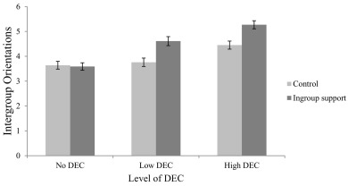

Fig. 1. Positive intergroup orientations as a function of depersonalized extended contact (DEC) and injunctive norms (Experiment 1). Error bars represent standard error.

Findings from Experiment 1 revealed, as predicted, that both DEC and injunctive norms for cross-group friendship are important predictors of desire for positive intergroup orientations, both interactively and independently. The effect size of the interactive effect was medium, whereas the main effects were high, particularly the main effect of DEC. Participants who learned that ingroup members generally have high levels of contact with outgroup members expressed more positive intergroup orientations than those who learned of low or no intergroup contact. Ingroup support also promoted more positive orientations toward outgroup members. However, the most interesting finding emerges as a result of the interplay between these normative influences. Extending prior research (Gómez et al., 2011; Turner et al., 2007; Wright et al., 1997), results showed that ingroup norms supporting cross-group friendship only impacted more positive intergroup orientations when respondents were aware of some degree of extended contact.

These findings suggest that injunctive norms in support of cross-group friendship may be effective to promote more positive intergroup orientations only to the extent that people also perceive convergent descriptive norms (DEC). That is, simply learning that ingroup members support cross-group friendship may not automatically improve intergroup orientations; it is also necessary for people to know that other members of their group actually engage in some contact with the outgroup. These results are in line with previous research showing that people follow the norm that is most salient in a situation when they perceive a contradiction between descriptive and injunctive norms (as is the case in the ‘no extended contact’ condition; see Cialdini et al., 1990).

Thus far, however, we have only tested the effects of injunctive norms in a general way, comparing effects when ingroup norms supporting cross-group friendships are or are not made explicit. Explicit norms supporting cross-group friendship may have different effects on intergroup outcomes depending on the degree to which people perceive consensus in those norms (e.g., Sechrist & Stangor, 2001). Thus, in Experiment 2, we tested how DEC and injunctive norms for cross-group friendship may interact in predicting intergroup outcomes, in relation to the degree of perceived consensus associated with ingroup normative support. Akin to Experiment 1, we expected that higher levels of DEC and greater consensus in ingroup norms supporting cross-group friendship would predict more positive intergroup orientations toward outgroup members, independently and interactively. We expected a main effect of DEC, such that higher levels of DEC would predict more positive intergroup orientations than lower levels of DEC. We also predicted a main effect of consensus in injunctive norms, such that participants who perceived greater consensus in ingroup norms supporting cross-group friendships would show more positive intergroup orientations than participants perceiving less consensus. Most importantly, we predicted an interaction such that greater consensus in ingroup support should predict more positive intergroup orientations in the low and high DEC conditions, but levels of consensus should not differentially predict intergroup orientations in the no DEC condition.

## 6. Experiment 2

The design and procedures used in Experiment 2 closely followed the design and procedures of Experiment 1. However, rather than manipulating injunctive norms through the presence or absence of information about ingroup support for cross-group friendships, in Experiment 2 we manipulated the degree of consensus associated with ingroup support for cross-group friendships. For practical purposes only, procedures for Experiment 2 also differed from those used in Experiment 1 in that participants were high school students rather than undergraduates, and the questionnaires were administered using a paper-and-pencil format rather than an online format.

### 6.1. Method

#### 6.1.1. Participants and design

One hundred and ninety-six high school students (67 girls, 129 boys; mean age = 15.46, *SD* = 0.93) voluntarily participated in the study with the consent of their school and parents. Each participant was randomly assigned to one of six experimental conditions in a 3 (DEC: no vs. low vs. high DEC) × 2 (injunctive norm consensus: low vs. high) design.

#### 6.1.2. Procedure and materials

Similar to Experiment 1, the materials distributed to participants consisted of three parts. First, participants completed a brief questionnaire in which they reported on their prior contact with immigrants, using the same measures as in Experiment 1, including contact quantity and quality, prior cross-group friendship, and extended contact (all αs > 0.71).

One week later, participants were randomly assigned to receive one of six versions of a fictitious newspaper article, which were varied to represent the factorial combination of the manipulations of DEC (no vs. low vs. high DEC) and degree of injunctive norm consensus (low vs. high consensus in ingroup support). Participants in each of the descriptive norm conditions received the same information about Spaniards' levels of contact as participants in Experiment 1. In addition, participants in the low ingroup consensus condition were informed that 22% of Spaniards support having immigrants as friends, whereas participants in the high consensus condition were informed that 78% of Spaniards support having immigrants as friends.

Finally, after reading the newspaper article, participants were asked to respond to the same measure used in Experiment 1 to assess their positive intergroup orientations, α = 0.89.